# Relationship between the Distance of Clusters and the F1-Score in K-Nearest Neighbors

Jim Greene

February 18, 2019

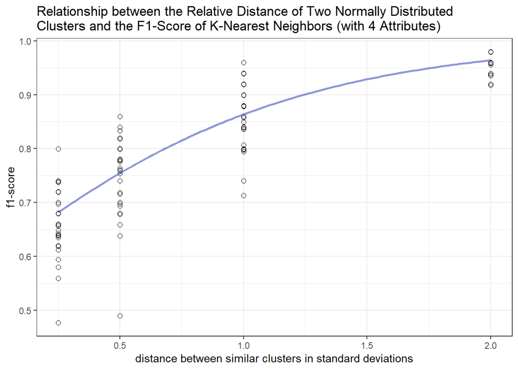

```r
f1_scores <- read_csv("./data/f1_scores.csv") %>%
  # I have created non-tidy data! Let's fix it.
  select(-c("X1")) %>%
  gather('0.25', '0.50', '1.00', '2.00', key = "distance", value = "score")
f1_scores$distance <- as.numeric(f1_scores$distance)

f1_scores_2 <- f1_scores %>%
  filter(score < 1) %>%
  mutate(log_odds = log(score / (1 - score)))

scores_lm <- lm(score ~ distance, data = f1_scores)
log_odds_lm <- lm(log_odds ~ distance, data = f1_scores_2)

ggplot(f1_scores_2, aes(x = distance, y = score)) +
  geom_point(size = 2, shape = 1) +
  stat_function(fun = function(x) 1/((1/exp(log_odds_lm$coef[1] + log_odds_lm$coef[2] * x)) + 1), size = 1, alpha = 0.5, color = "#2030b0") +
  labs(x = "distance between similar clusters in standard deviations", y = "f1-score", title = "Relationship between the Relative Distance of Two Normally Distributed\nClusters and the F1-Score of K-Nearest Neighbors (with 4 Attributes)") +
  theme_bw()
```

The f1-scores can be predicted with this model:
$$\underbrace{\hat{Y}_i}_\text{Average F1-Score} \quad \underbrace{X_i}_\text{Distance}
\\ \quad
\\
\hat{Y}_i = [\frac{1}{e^{0.4002 + 1.4449 X_i}} + 1]^{-1}$$

### Explanation

I generated a cluster of 100 points in 4-space at the centroid (0,0,0,0) with a normal distribution and a standard deviation of 1 in all directions. I assigned all of these data points to the class ‘A’.

I then created 4 similar clusters, each assigned to class ‘B’. These four clusters were centered at (0.25,0,0,0), (0.5,0,0,0), (1,0,0,0), and (2,0,0,0).

I compiled these into four datasets, each with the ‘A’ cluster and one of the ‘B’ clusters.

I then ran a k-nearest neighbors classification 40 times on each of the four datasets with k = 9, recording the macro f1-scores.

### Details

I first created this simple regression, which is not good because the f1-score is a percentage rather than a continouously increasing value:

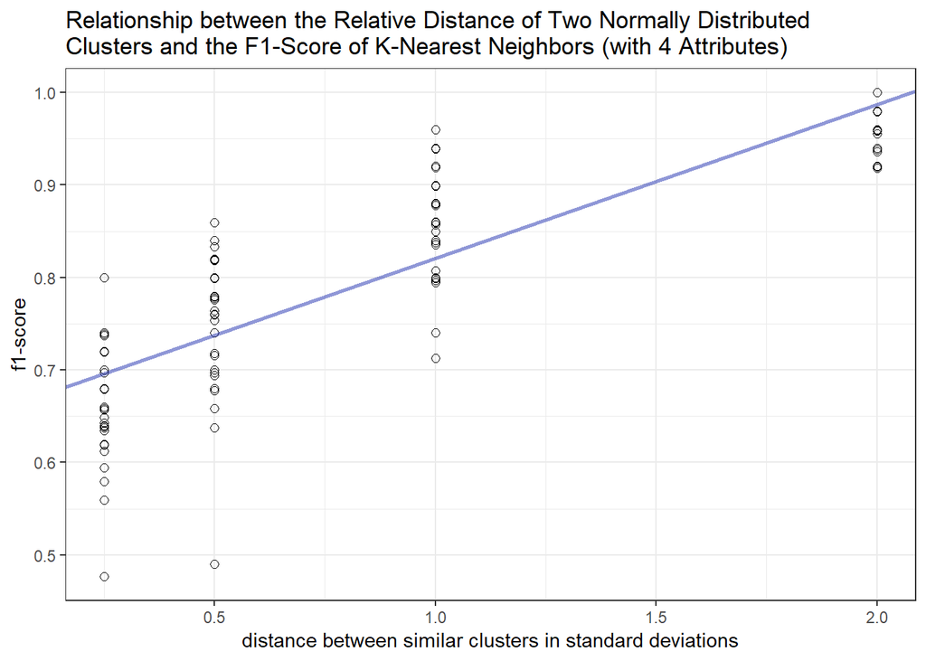

```r
ggplot(f1_scores, aes(x = distance, y = score)) +
  geom_point(shape = 1, size = 2) +
  geom_abline(slope = scores_lm$coefficients[2], intercept = scores_lm$coefficients[1], size = 1, alpha = 0.5, color = "#2030b0") +
  labs(x = "distance between similar clusters in standard deviations", y = "f1-score", title = "Relationship between the Relative Distance of Two Normally Distributed\nClusters and the F1-Score of K-Nearest Neighbors (with 4 Attributes)") +
  theme_bw()
```

I decided to convert the percentages into the log-odds to resolve this. In the process a few values of 100% needed to be dropped because they cause the transformation to divide by zero.

$$\text{odds} = \frac{\text{percentage}}{1-\text{percentage}}$$
$$\text{log-odds} = \text{log}(\text{odds})$$

These are the diagnostic plots from after the transformation:

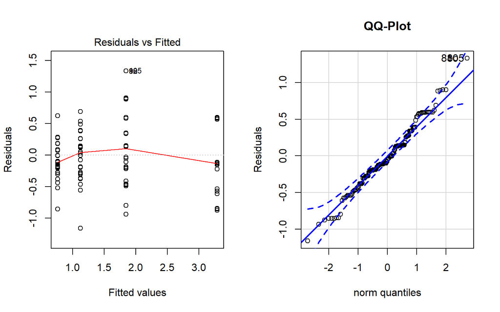

```
## [1] 105  88
```

```r
par(mfrow = c(1,2))
plot(log_odds_lm, which = 1)
qqPlot(log_odds_lm$residuals, main = "QQ-Plot", ylab = "Residuals")
```

The errors are mostly normal, but it’s possible that this experiment tends to have more extreme outliers.

```r
pander(summary(log_odds_lm))
```

|  | Estimate | Std. Error | t value | Pr(>\|t\|) |
| --- | --- | --- | --- | --- |
| **(Intercept)** | 0.4002 | 0.06225 | 6.429 | 1.573e-09 |
| **distance** | 1.445 | 0.05627 | 25.68 | 3.717e-57 |

Fitting linear model: log_odds ~ distance

| Observations | Residual Std. Error | $R^2$ | Adjusted $R^2$ |
| --- | --- | --- | --- |
| 154 | 0.4531 | 0.8127 | 0.8115 |

### Data (Perfect scores included)

```r
datatable(f1_scores, options = list(lengthMenu = c(10,40,160)))
```

|  | distance | score |
| --- | --- | --- |
| 1 | 0.25 | 0.594155844155844 |
| 2 | 0.25 | 0.67948717948718 |
| 3 | 0.25 | 0.579831932773109 |
| 4 | 0.25 | 0.68 |
| 5 | 0.25 | 0.737373737373737 |
| 6 | 0.25 | 0.67948717948718 |
| 7 | 0.25 | 0.63768115942029 |
| 8 | 0.25 | 0.68 |
| 9 | 0.25 | 0.61984793917567 |
| 10 | 0.25 | 0.648615130219099 |

[output cut: 150 more lines]

Click the “Code” button to see the Python script that generated the data.

```python
# This is the Python code I used to generate the data.
import random as rand
import numpy as np
import pandas as pd
from sklearn.model_selection import train_test_split
from sklearn.neighbors import KNeighborsClassifier
from sklearn.metrics import f1_score
rand.seed()
def get_knn_f1(attributes, targets, test_size, k, seed = None):
    attributes = attributes.astype(np.float64)
    train_data, test_data, train_target, test_target = train_test_split(
            attributes, targets, test_size = test_size, random_state = seed)

    classifier = KNeighborsClassifier(n_neighbors = k)
    classifier.fit(train_data, train_target)
    predictions = classifier.predict(test_data)

    return (f1_score(test_target, predictions, average = 'macro'))
def generate_cluster(n, target, w_shift = 0):
    data = -1

    for i in range(n):
        # This article to helped me generate random directions:
        # http://mathworld.wolfram.com/HyperspherePointPicking.html
        x1 = 2
        x2 = 0
        x3 = 2
        x4 = 0

        while x1**2 + x2**2 >= 1:
            x1 = rand.uniform(-1, 1)
            x2 = rand.uniform(-1, 1)

        while x3**2 + x4**2 >= 1:
            x3 = rand.uniform(-1, 1)
            x4 = rand.uniform(-1, 1)

        radius = rand.normalvariate(0, 1)

        w = x1 * radius + w_shift
        x = x2 * radius
        y = x3 * np.sqrt((1 - x1**2 - x2**2)/(x3**2 + x4**2)) * radius
        z = x4 * np.sqrt((1 - x1**2 - x2**2)/(x3**2 + x4**2)) * radius

        if type(data) == np.ndarray:
            data = np.append(data, [[w, x, y, z, target]], axis = 0)
        else:
            data = np.array([[w, x, y, z, target]])

    return(data)
K = 9
SAMPLE_SIZE = 40
CLUSTER_SIZE = 100
f1_scores_025 = []
for i in range(SAMPLE_SIZE):
    data_025 = np.append(generate_cluster(CLUSTER_SIZE, 'A'), generate_cluster(
            CLUSTER_SIZE, 'B', 0.25))
    data_025 = np.reshape(data_025, (-1,5))
    f1_scores_025.append(get_knn_f1(
            data_025[...,:4], data_025[...,4], 0.25, K))
f1_scores_050 = []
for i in range(SAMPLE_SIZE):
    data_050 = np.append(generate_cluster(CLUSTER_SIZE, 'A'), generate_cluster(
            CLUSTER_SIZE, 'B', 0.5))
    data_050 = np.reshape(data_050, (-1,5))
    f1_scores_050.append(get_knn_f1(
            data_050[...,:4], data_050[...,4], 0.25, K))
f1_scores_100 = []
for i in range(SAMPLE_SIZE):
    data_100 = np.append(generate_cluster(CLUSTER_SIZE, 'A'), generate_cluster(
            CLUSTER_SIZE, 'B', 1))
    data_100 = np.reshape(data_100, (-1,5))
    f1_scores_100.append(get_knn_f1(
            data_100[...,:4], data_100[...,4], 0.25, K))
f1_scores_200 = []
for i in range(SAMPLE_SIZE):
    data_200 = np.append(generate_cluster(CLUSTER_SIZE, 'A'), generate_cluster(
            CLUSTER_SIZE, 'B', 2))
    data_200 = np.reshape(data_200, (-1,5))
    f1_scores_200.append(get_knn_f1(
            data_200[...,:4], data_200[...,4], 0.25, K))
pd.DataFrame({'0.25' : f1_scores_025, '0.50' : f1_scores_050,
              '1.00' : f1_scores_100, '2.00' : f1_scores_200}).to_csv(
    "f1_scores.csv")
```